# Exploratory Data Analysis using R

Muriithi Nduta Ruth (MR. N)

# Research Question

[output not shown]

## 1. Defining the Question

#### 1.1 Specifying the data analytic objective

> Our main aim is to do thorough exploratory data analysis for univariate and bivariate data and come up with recommendations for our client.

#### 1.2 Defining the metric for success

> We aim to build elaborate visualizations for univariate and bivariate analysis

#### 1.3 Recording the Experimental Design

> 1. Loading the data
> 2. Checking the data
> 3. Tidying the data
> 4. Univariate Analysis
> 5. Bivariate Analysis
> 6. Challenging the solution
> 7. Recommendations
> 8. Follow up questions

#### 1.4 Data Relevance

> The data provided was relevant for our analysis.

## 2.Loading and reading Our Datasets

```r
library(tidyverse)
ads <- read.csv("~/moringa-school-projects/RYouWithMe/advertising.csv")
view(ads)
```

*Checking the data summary*

```r
summary(ads)
```

```
##  Daily.Time.Spent.on.Site      Age         Area.Income    Daily.Internet.Usage
##  Min.   :32.60            Min.   :19.00   Min.   :13996   Min.   :104.8
##  1st Qu.:51.36            1st Qu.:29.00   1st Qu.:47032   1st Qu.:138.8
##  Median :68.22            Median :35.00   Median :57012   Median :183.1
##  Mean   :65.00            Mean   :36.01   Mean   :55000   Mean   :180.0
##  3rd Qu.:78.55            3rd Qu.:42.00   3rd Qu.:65471   3rd Qu.:218.8
##  Max.   :91.43            Max.   :61.00   Max.   :79485   Max.   :270.0
##  Ad.Topic.Line          City                Male         Country
##  Length:1000        Length:1000        Min.   :0.000   Length:1000
##  Class :character   Class :character   1st Qu.:0.000   Class :character
##  Mode  :character   Mode  :character   Median :0.000   Mode  :character
##                                        Mean   :0.481
##                                        3rd Qu.:1.000
##                                        Max.   :1.000
##   Timestamp         Clicked.on.Ad
##  Length:1000        Min.   :0.0
##  Class :character   1st Qu.:0.0
##  Mode  :character   Median :0.5
##                     Mean   :0.5
##                     3rd Qu.:1.0
##                     Max.   :1.0
```

From the table above, we can see all our measures of central tendency (median, mean).

*Checking top and bottom rows and columns*

```r
tail(ads)
```

```
##      Daily.Time.Spent.on.Site Age Area.Income Daily.Internet.Usage
## 995                     43.70  28    63126.96               173.01
## 996                     72.97  30    71384.57               208.58
## 997                     51.30  45    67782.17               134.42
## 998                     51.63  51    42415.72               120.37
## 999                     55.55  19    41920.79               187.95
## 1000                    45.01  26    29875.80               178.35
##                             Ad.Topic.Line          City Male
## 995         Front-line bifurcated ability  Nicholasland    0
## 996         Fundamental modular algorithm     Duffystad    1
## 997       Grass-roots cohesive monitoring   New Darlene    1
## 998          Expanded intangible solution South Jessica    1
## 999  Proactive bandwidth-monitored policy   West Steven    0
## 1000      Virtual 5thgeneration emulation   Ronniemouth    0
##                     Country           Timestamp Clicked.on.Ad
## 995                 Mayotte 2016-04-04 03:57:48             1
## 996                 Lebanon 2016-02-11 21:49:00             1
## 997  Bosnia and Herzegovina 2016-04-22 02:07:01             1
## 998                Mongolia 2016-02-01 17:24:57             1
## 999               Guatemala 2016-03-24 02:35:54             0
## 1000                 Brazil 2016-06-03 21:43:21             1
```

```r
head(ads)
```

```
##   Daily.Time.Spent.on.Site Age Area.Income Daily.Internet.Usage
## 1                    68.95  35    61833.90               256.09
## 2                    80.23  31    68441.85               193.77
## 3                    69.47  26    59785.94               236.50
## 4                    74.15  29    54806.18               245.89
## 5                    68.37  35    73889.99               225.58
## 6                    59.99  23    59761.56               226.74
##                           Ad.Topic.Line           City Male    Country
## 1    Cloned 5thgeneration orchestration    Wrightburgh    0    Tunisia
## 2    Monitored national standardization      West Jodi    1      Nauru
## 3      Organic bottom-line service-desk       Davidton    0 San Marino
## 4 Triple-buffered reciprocal time-frame West Terrifurt    1      Italy
## 5         Robust logistical utilization   South Manuel    0    Iceland
## 6       Sharable client-driven software      Jamieberg    1     Norway
##             Timestamp Clicked.on.Ad
## 1 2016-03-27 00:53:11             0
## 2 2016-04-04 01:39:02             0
## 3 2016-03-13 20:35:42             0
## 4 2016-01-10 02:31:19             0
## 5 2016-06-03 03:36:18             0
## 6 2016-05-19 14:30:17             0
```

*Checking the classes*

```r
class(ads)
```

```
## [1] "data.frame"
```

*Checking the number of rows and in our dataset*

```r
cat("Rows in dataset:", nrow(ads), "\nCols in dataset:", ncol(ads))
```

```
## Rows in dataset: 1000
## Cols in dataset: 10
```

```r
cat("\nThe dimension of the dataset is:", dim(ads))
```

```
##
## The dimension of the dataset is: 1000 10
```

*Range of Time Spent on Site by users*

```r
site.time.range <- range(ads$Daily.Time.Spent.on.Site)
cat("The Range of Time Spent on Site by users is:",site.time.range)
```

```
## The Range of Time Spent on Site by users is: 32.6 91.43
```

*Range of Daily Internet Usage*

```r
internet.time.range <- range(ads$Daily.Internet.Usage)
cat("The Range of Daily Internet Usage is:", internet.time.range)
```

```
## The Range of Daily Internet Usage is: 104.78 269.96
```

*Range of Age*

```r
age.range <- range(ads$Age)
cat("The Range of Users' age is:",age.range)
```

```
## The Range of Users' age is: 19 61
```

*Range of Income*

```r
income.range <- range(ads$Area.Income)
cat("The Range of Users' income is:",income.range)
```

```
## The Range of Users' income is: 13996.5 79484.8
```

*Structure of our dataframe*

```r
str(ads)
```

```
## 'data.frame':    1000 obs. of  10 variables:
##  $ Daily.Time.Spent.on.Site: num  69 80.2 69.5 74.2 68.4 ...
##  $ Age                     : int  35 31 26 29 35 23 33 48 30 20 ...
##  $ Area.Income             : num  61834 68442 59786 54806 73890 ...
##  $ Daily.Internet.Usage    : num  256 194 236 246 226 ...
##  $ Ad.Topic.Line           : chr  "Cloned 5thgeneration orchestration" "Monitored national standardization" "Organic bottom-line service-desk" "Triple-buffered reciprocal time-frame" ...
##  $ City                    : chr  "Wrightburgh" "West Jodi" "Davidton" "West Terrifurt" ...
##  $ Male                    : int  0 1 0 1 0 1 0 1 1 1 ...
##  $ Country                 : chr  "Tunisia" "Nauru" "San Marino" "Italy" ...
##  $ Timestamp               : chr  "2016-03-27 00:53:11" "2016-04-04 01:39:02" "2016-03-13 20:35:42" "2016-01-10 02:31:19" ...
##  $ Clicked.on.Ad           : int  0 0 0 0 0 0 0 1 0 0 ...
```

Our dataset is of type dataframe, with 1000 records and 10 variables. 3 variables of tye numeric, 3 integer types, 4 character types including the date and time which will be converted to the standard format.

*Converting the date and time*

```r
class(ads$Timestamp)
```

```
## [1] "character"
```

```r
ads$Timestamp <- strptime(paste( ads$Timestamp), format = "%Y-%m-%d %H:%M:%S",tz="UTC")
class(ads$Timestamp)
```

```
## [1] "POSIXlt" "POSIXt"
```

*Checking for outliers on the numerical columns using boxplots*

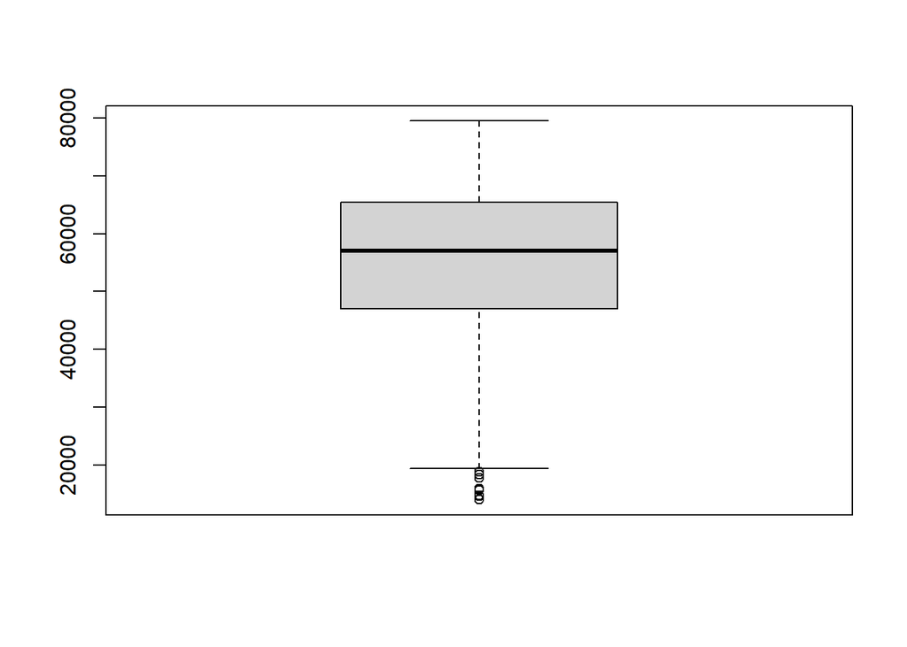

```r
boxplot(ads$Area.Income)
```

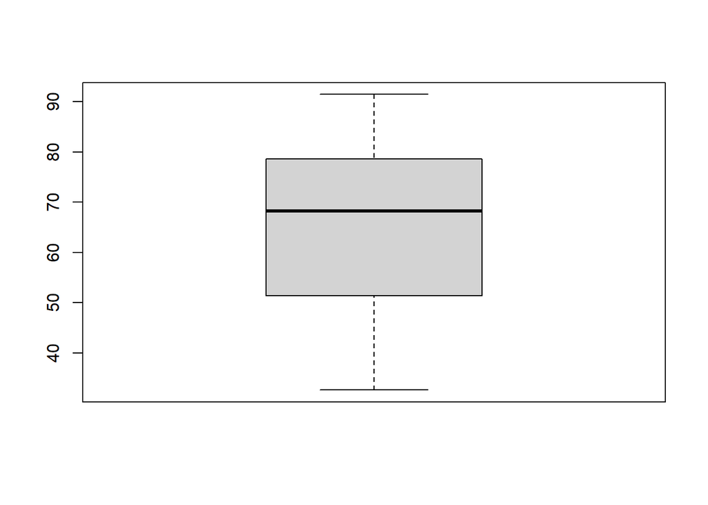

```r
boxplot(ads$Daily.Time.Spent.on.Site)
```

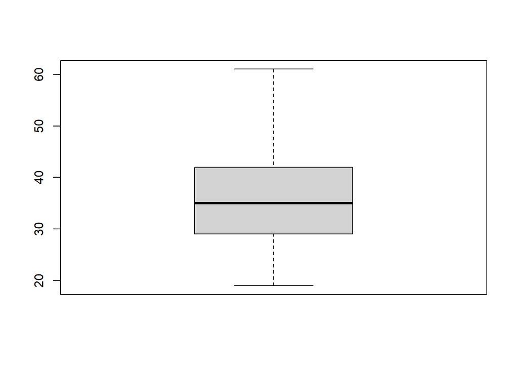

```r
boxplot(ads$Age)
```

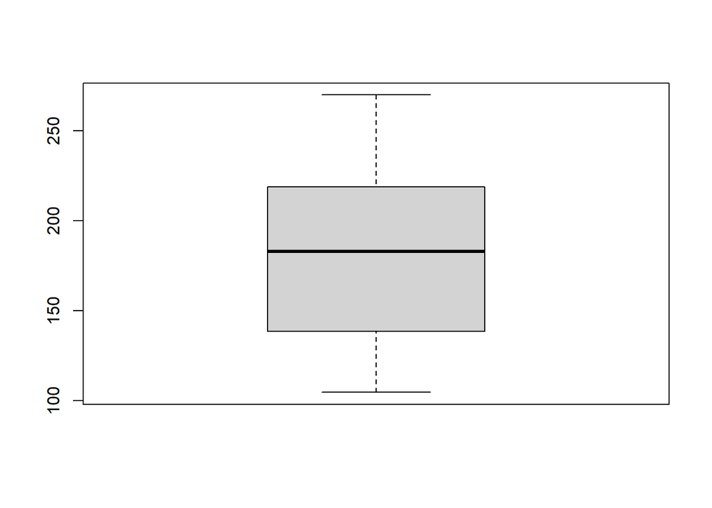

```r
boxplot(ads$Daily.Internet.Usage)
```

Only one variable had outliers, Area.Income.

*Removing outliers;*

We’ll remove outliers by limiting extreme values in the statistical data to reduce the effect of possibly spurious outliers.

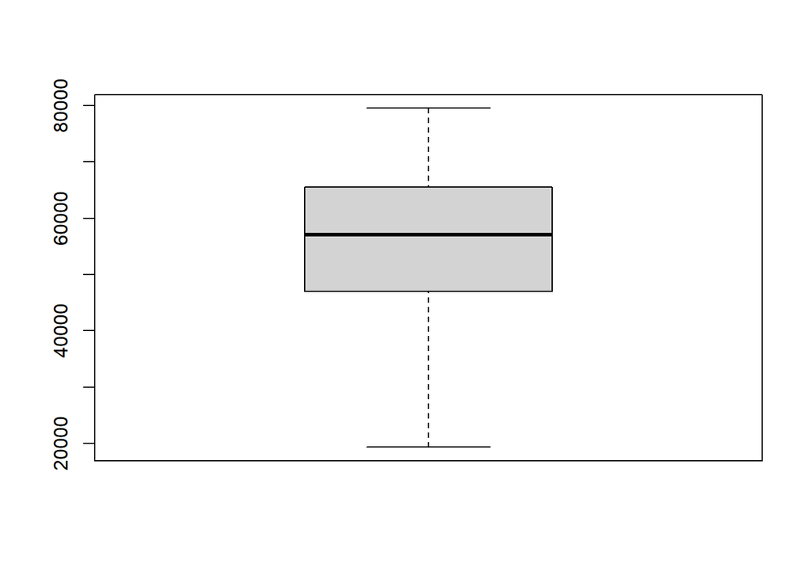

```r
bench <- 47032 - 1.5 * IQR(ads$Area.Income)
ads$Area.Income[ads$Area.Income < bench]<- bench

boxplot(ads$Area.Income)
```

The boxplot shows that the outliers in that column have been removed.

*Checking for duplicates*

```r
sum(duplicated(ads))
```

```
## [1] 0
```

There are no duplicates in our data

*Checking for missing values*

```r
colSums(is.na(ads))
```

```
## Daily.Time.Spent.on.Site                      Age              Area.Income
##                        0                        0                        0
##     Daily.Internet.Usage            Ad.Topic.Line                     City
##                        0                        0                        0
##                     Male                  Country                Timestamp
##                        0                        0                        0
##            Clicked.on.Ad
##                        0
```

The dataset has no missing values in any of the columns.

# Exploratory Data Analysis

```r
install.packages("dataMaid", repos = "http://cran.us.r-project.org")
install.packages("inspectdf", repos = "http://cran.us.r-project.org")
```

*Calling the libraries*

```r
library(dplyr)
library(inspectdf)
```

The 2 packages will give us more insights on our data.

```r
inspect_cat(ads)
```

```
## # A tibble: 3 x 5
##   col_name        cnt common                       common_pcnt levels
##   <chr>         <int> <chr>                              <dbl> <named list>
## 1 Ad.Topic.Line  1000 Adaptive 24hour Graphic Int~       0.1   <tibble [1,000 x~
## 2 City            969 Lisamouth                          0.3   <tibble [969 x 3~
## 3 Country         237 Czech Republic                     0.900 <tibble [237 x 3~
```

**common_pcnt**, the percentage of each column occupied by the most common level shown in **common.**

## Bivariate Analysis visualization

Here we check for correlation between the different columns and the target variable Clicked.On.Ad.

```r
inspect_cor(ads, df2 = NULL, method = "pearson", with_col = 'Clicked.on.Ad', alpha = 0.05)
```

```
## # A tibble: 5 x 7
##   col_1         col_2                    corr   p_value   lower   upper pcnt_nna
##   <chr>         <chr>                   <dbl>     <dbl>   <dbl>   <dbl>    <dbl>
## 1 Clicked.on.Ad Daily.Internet.Usage  -0.787  3.74e-136 -0.809  -0.762       100
## 2 Clicked.on.Ad Daily.Time.Spent.on.~ -0.748  2.29e-123 -0.774  -0.719       100
## 3 Clicked.on.Ad Age                    0.493  1.55e- 54  0.444   0.538       100
## 4 Clicked.on.Ad Area.Income           -0.477  3.04e- 51 -0.523  -0.428       100
## 5 Clicked.on.Ad Male                  -0.0380 2.30e-  1 -0.0998  0.0240      100
```

The summary above covers Pearson’s correlation coefficients for all the numeric columns, compared against the *Clicked.On.Ads* column.

Across the board, we can see that there are negative correlation values for *Daily.Internet.Usage*, *Daily.Time.Spent.on.Site*, *Area Income*. The only positive correlation is between *Clicked.On.Ad* and *Age*.

```r
inspect_cor(ads, df2 = NULL, method = "pearson", alpha = 0.05)
```

```
## # A tibble: 15 x 7
##    col_1           col_2                 corr   p_value   lower   upper pcnt_nna
##    <chr>           <chr>                <dbl>     <dbl>   <dbl>   <dbl>    <dbl>
##  1 Clicked.on.Ad   Daily.Internet.U~ -0.787   3.74e-136 -0.809  -0.762       100
##  2 Clicked.on.Ad   Daily.Time.Spent~ -0.748   2.29e-123 -0.774  -0.719       100
##  3 Daily.Internet~ Daily.Time.Spent~  0.519   2.80e- 60  0.472   0.563       100
##  4 Clicked.on.Ad   Age                0.493   1.55e- 54  0.444   0.538       100
##  5 Clicked.on.Ad   Area.Income       -0.477   3.04e- 51 -0.523  -0.428       100
##  6 Daily.Internet~ Age               -0.367   4.38e- 31 -0.420  -0.312       100
##  7 Daily.Internet~ Area.Income        0.339   8.86e- 27  0.283   0.393       100
##  8 Age             Daily.Time.Spent~ -0.332   1.22e- 25 -0.386  -0.275       100
##  9 Area.Income     Daily.Time.Spent~  0.312   6.35e- 23  0.255   0.367       100
## 10 Area.Income     Age               -0.182   8.44e-  9 -0.242  -0.122       100
## 11 Clicked.on.Ad   Male              -0.0380  2.30e-  1 -0.0998  0.0240      100
## 12 Male            Daily.Internet.U~  0.0280  3.76e-  1 -0.0340  0.0898      100
## 13 Male            Age               -0.0210  5.06e-  1 -0.0829  0.0410      100
## 14 Male            Daily.Time.Spent~ -0.0190  5.50e-  1 -0.0808  0.0431      100
## 15 Male            Area.Income        0.00252 9.36e-  1 -0.0595  0.0645      100
```

```r
install.packages("PerformanceAnalytics")
```

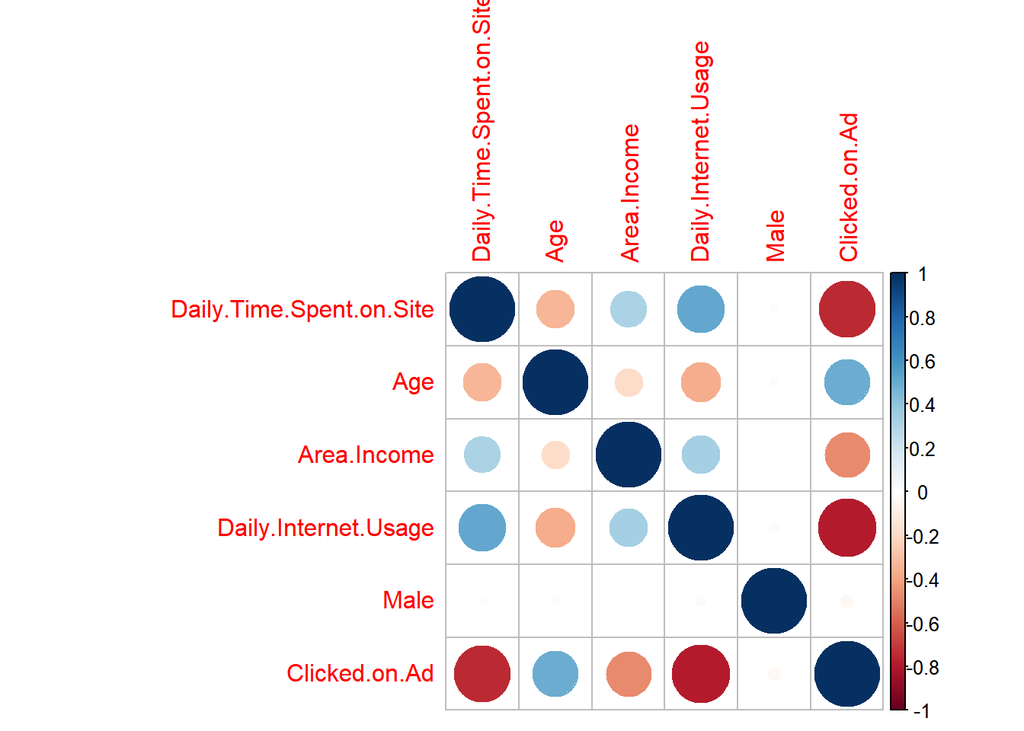

```r
install.packages("corrplot")
library(corrplot)
ads_num <- Filter(is.numeric, ads)
corrplot(cor(ads_num))
```

The *Daily internet usage* and *Daily time spent on the site* columns have a large positive correlation and so does the *Clicked.On.Ad* and *age columns*.

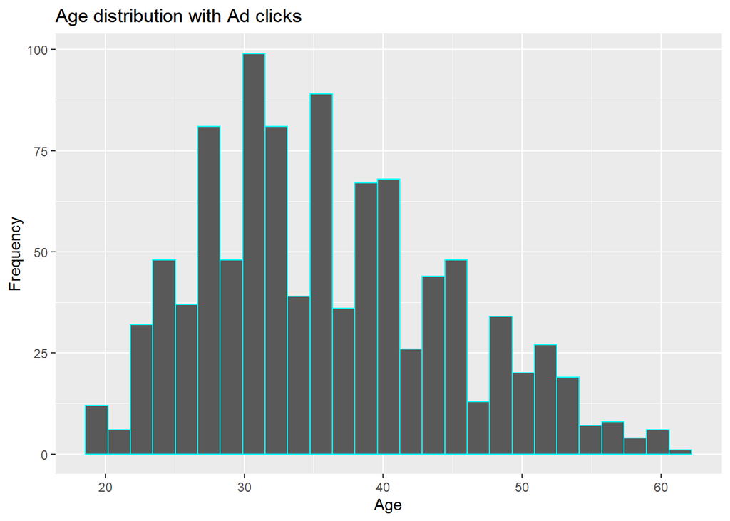

```r
library(ggplot2)

ggplot(data = ads, aes(x = Age, fill = Clicked.on.Ad))+
    geom_histogram(bins = 27, color = 'cyan') +
    labs(title = 'Age distribution with Ad clicks', x = 'Age', y = 'Frequency', fill = 'Clicked.on.Ad') +
        scale_color_brewer(palette = 'Set2')
```

**Income and Click on Ad distribution**

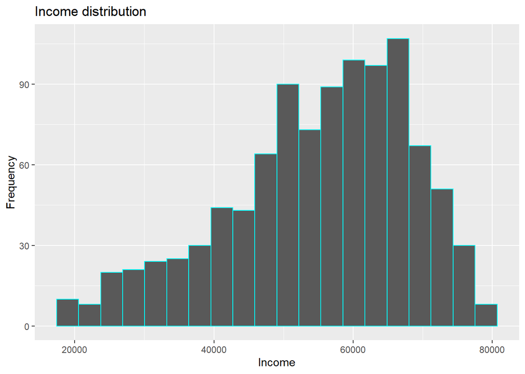

```r
ggplot(data = ads, aes(x = Area.Income, fill = Clicked.on.Ad))+
    geom_histogram(bins = 20, color = 'cyan') +
    labs(title = 'Income distribution', x = 'Income', y = 'Frequency', fill = 'Clicked.on.Ad') +
        scale_color_brewer(palette = 'Set1')
```

**Daily Internet Use and the clicked on ad relationship**

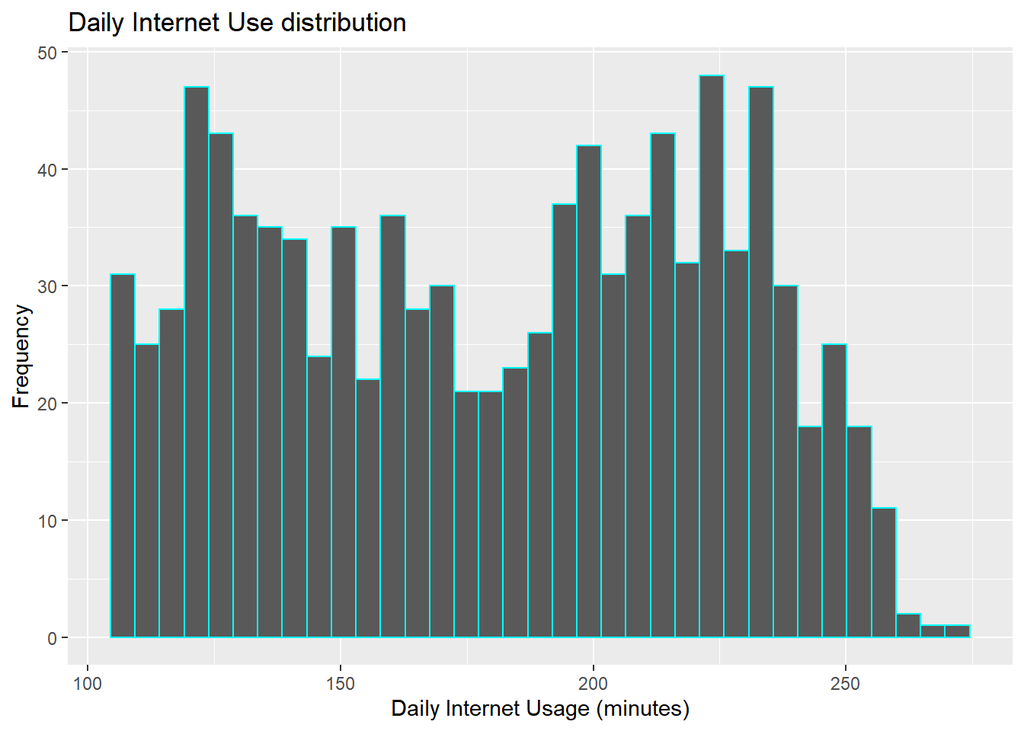

```r
ggplot(data = ads, aes(x = Daily.Internet.Usage, fill = Clicked.on.Ad))+
    geom_histogram(bins = 35, color = 'cyan') +
    labs(title = 'Daily Internet Use distribution', x = 'Daily Internet Usage (minutes)', y = 'Frequency', fill = 'Clicked.on.Ad') +
        scale_color_brewer(palette = 'Set1')
```

**Daily Time Spent on Site and the clicked on ad relationship**

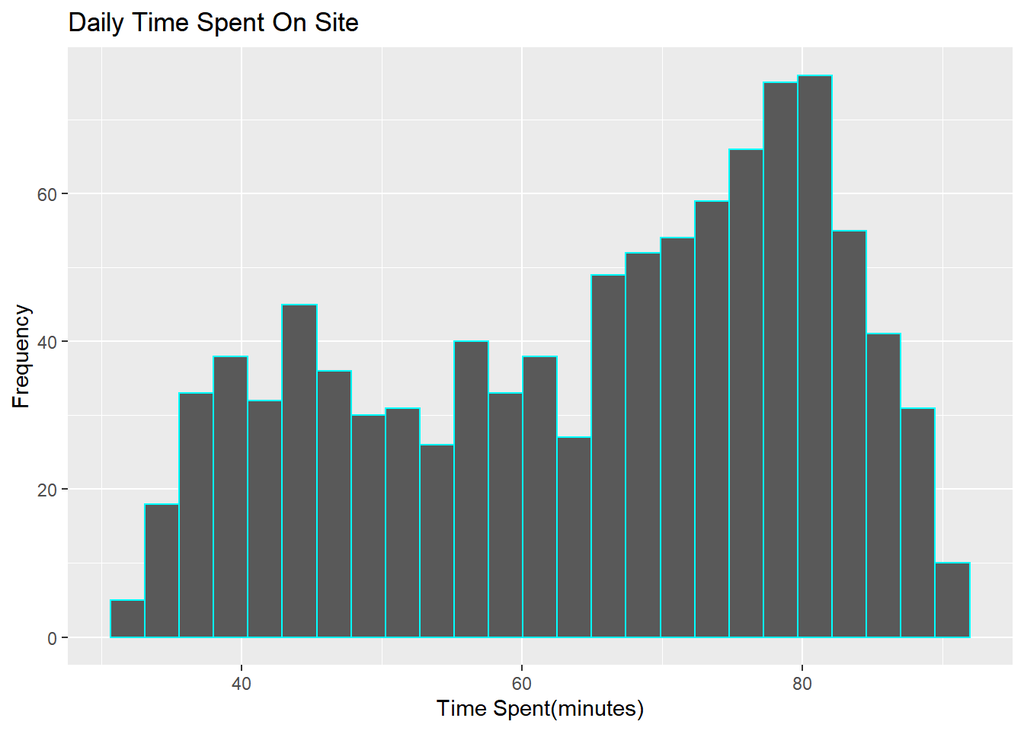

```r
ggplot(data = ads, aes(x = Daily.Time.Spent.on.Site, fill = Clicked.on.Ad))+
    geom_histogram(bins = 25, color = 'cyan') +
    labs(title = 'Daily Time Spent On Site', x = 'Time Spent(minutes)', y = 'Frequency', fill = 'Clicked.on.Ad') +
        scale_color_brewer(palette = 'Set1')
```

**Daily Time Spent on Site and the Income relationship**